# 2IS50 – Software Development for Engineers – 2022-2023

## Lecture 2.A (Python)

Lecturer: Tom Verhoeff

Also see the book **Think Python** (2e), by Allen Downey

### Review of Lecture 1.B

- Software Engineering, more than programming
- Dealing with errors
  - Python coding standard
  - `assert` statement
  - Pair programming
  - Systematic testing: manually
- Version control: **Git**
- **PyCharm**: Python Integrated Development Environment (IDE)

### Preview of Lecture 2.A

- Organizing data: lists and tuples.
  - Sharing, aliasing
- Anonymous functions: `lambda` expressions
- *Sequences,* *Iterables,* and `for`-loops
- Reading from and writing to text files
- Turtle graphics

## Organizing Data

Programs manipulate data values through variables.

So far, our programs can deal with *small* amounts of *simple* data:

- integers
- floating point numbers
- booleans
- strings

In Python, integers and strings can be become very large.

Still, it is hard to encode more complex data in them.

Examples of more complex data:

- A polynomial
- A matrix or a table
- A graph with labeled nodes and labeled (un)directed edges
- Etc.

## Lists & Tuples (later: Sets & Dicts)

- These are **container** or **collection** types
- They hold *multiple* items
  - Compare to mathematical sets
- Items are organized in some way
- Collections can be operated on *as a whole*:
  - inspect, query
  - modify
  - break apart
  - combine

## Lists (a CS miracle)

- Each value in the `list` type is a *sequence* of values.
- **Order** and **multiplicity** (number of occurrences) are relevant.
- List literals:
  - `[]` (**empty list**)
  - `[item_1, item_2, ...]`
- The values in a sequence can have different types, including `list` (nesting).
  - `[True, [3.14, "abc"]]`

```python
subjects = ['mathematics', 'computer science', 'programming', 'modeling']
subjects
```

```
['mathematics', 'computer science', 'programming', 'modeling']
```

### Standard operations on sequences

- test if non-empty: use it as boolean expression
- `len`, for length
- *indexing* (`...[...]`), for access to single item
- *slicing* (`...[...:...]`), for access to subsequence of items
- `in`, `not in`, for membership
- concatenation (`+`) and replication (`*`)
- comparisons with `==`, `!=`, `<`, `<=`, `>`, `>=` (**lexicographic order**)
- `.count(target)`, `.index(item)`

```python
def classify(lst: list) -> None:
    """Classify a list as empty or non-empty.
    """
    if lst:
        print("{} is not empty".format(lst))
    else:
        print("it is empty")
```

```python
classify([]), classify(subjects);  # semicolon suppresses expression result
```

```
it is empty
['mathematics', 'computer science', 'programming', 'modeling'] is not empty
```

### Anti-patterns for emptiness check

How *not* to check whether list `lst` is not empty:

- `lst != []`
- `len(lst) > 0`

How to do it:

- `lst` (when used where a boolean is expected)

### More examples of list operations

```python
len([]), len(subjects)
```

```
(0, 4)
```

```python
subjects[0], subjects[3]  # indexing starts at 0
```

```
('mathematics', 'modeling')
```

```python
subjects[len(subjects)]  # this is out of bounds: IndexError
```

```
---------------------------------------------------------------------------
IndexError                                Traceback (most recent call last)
/var/folders/dq/bbdqxxcx30zdyfdd26t6vj4c0000gq/T/ipykernel_19616/4051063596.py in <module>
----> 1 subjects[len(subjects)]  # this is out of bounds: IndexError

IndexError: list index out of range
```

```python
subjects[-1]  # negative index starts from the end
```

```
'modeling'
```

```python
subjects[1:3]  # from index 1 up to and excluding index 3
```

```
['computer science', 'programming']
```

```python
subjects[:2], subjects[2:]  # can omit start or stop
```

```
(['mathematics', 'computer science'], ['programming', 'modeling'])
```

```python
subjects[:]  # omitting both start and stop copies all items
```

```
['mathematics', 'computer science', 'programming', 'modeling']
```

```python
subjects[:4:2]  # optionally include step size
```

```
['mathematics', 'programming']
```

```python
subjects[::-1]  # negative step size for reversed
```

```
['modeling', 'programming', 'computer science', 'mathematics']
```

```python
"computer science" in subjects, "data science" not in subjects
```

```
(True, True)
```

```python
subjects + 4 * ["fun"]
```

```
['mathematics',
 'computer science',
 'programming',
 'modeling',
 'fun',
 'fun',
 'fun',
 'fun']
```

```python
subjects.count("programming"), subjects.count("informatics")
```

```
(1, 0)
```

```python
subjects.index("mathematics")  # returns index where target occurs
```

```
0
```

```python
subjects.index("informatics")  # ValueError if not present
```

```
---------------------------------------------------------------------------
ValueError                                Traceback (most recent call last)
/var/folders/dq/bbdqxxcx30zdyfdd26t6vj4c0000gq/T/ipykernel_19616/3009044573.py in <module>
----> 1 subjects.index("informatics")  # ValueError if not present

ValueError: 'informatics' is not in list
```

### Lists are *mutable*

Use indexed or sliced list as target in assignment statement to modify it.

```python
subjects[1] = "informatics"
subjects
```

```
['mathematics', 'informatics', 'programming', 'modeling']
```

Other ways of modifying a list:

- `.append(item)` (appends item at end)
- `.extend(lst)` (appends all items from lst at end)
- `.clear()` (removes all items)
- `.pop()` (removes last item)
- `.remove(item)` (removes given item)
- `.reverse()` (reverses list)
- `.sort()` (sorts list)
- Use **TAB for code completion** and **SHIFT TAB for documentation**

```python
subjects. # TAB-complete to subject.sort, then add parentheses: subjects.sort()
subjects
```

```
  File "/var/folders/dq/bbdqxxcx30zdyfdd26t6vj4c0000gq/T/ipykernel_19616/2581254541.py", line 1
    subjects. # TAB-complete to subject.sort, then add parentheses: subjects.sort()
              ^
SyntaxError: invalid syntax
```

### Map, Filter, Reduce

Very common operations on lists (actually, on *iterables*) are:

- **map**: apply a given function to each item of a given list
- **filter**: from a given list, select those items for which a given function returns `True`
- **reduce**: combine all items in a given list using a given binary operator E.g. `[1, 2, 3, 4] -> 1 + 2 + 3 + 4`

### *Python Standard Library* - built-in functions

- `map(func, lst)` returns iterable with `func` applied to each item in `lst`
- `filter(func, lst)` returns iterable with items from `lst` for which `func` returns `True`
- `functools.reduce(op, lst)`, where `op` is function with 2 arguments (binary operator), returns result of evaluating **accumulation** expression `lst[0] op lst[1] op ... op lst[-1]`
- `functools.reduce(op, lst, initial)` first prepends `initial` to make list non-empty

### Notes

- These operations are *lazy* and do not return a list object
- Turn result of `map` and `filter` into list by applying `list`.

```python
map(len, subjects)  # result is a map-object
```

```
<map at 0x7faa7841b970>
```

```python
list(map(len, subjects))
```

```
[11, 11, 11, 8]
```

### Anonymous functions: `lambda` expressions

Syntax of **`lambda` expression**:

```
lambda parameter_list: expression
```

Here, `lambda` is a reserved word (name of the Greek letter $\lambda$).

Semantics:

1. Behave as function `f` defined by

```
def f(parameter_list):
    return expression
```

except that the function is not given any name.

```python
list(filter(lambda s: len(s) == 11, subjects))
```

```
['mathematics', 'informatics', 'programming']
```

```python
from functools import reduce

reduce(lambda s, t: s + " | " + t, subjects)
```

```
'mathematics | informatics | programming | modeling'
```

#### Notes for `lambda` expressions

- In general, prefer `def` to define functions

  Advantages:
  - They have a name
  - Easier to add type hints
  - Can add docstring
  - Easier to reuse in more places
- Advantage of `lambda` expression: concise
- *Avoid* assigning `lambda` expression to name
  - Even though it works
  - In that case, use `def`

```python
from functools import reduce  # all imports will be given in Final Test

operator = lambda s, t: s + " | " + t  # AVOID THIS

reduce(operator, subjects)
```

```
'mathematics | informatics | programming | modeling'
```

### List Comprehension

Functions `map` and `filter` are nice to construct lists.

Even nicer is *list comprehension*, with syntax

```
[ expression for name in iterable ]

[ expression for name in iterable if condition ]
```

Semantics:

- Construct the list consisting of
  - all `expression` values obtained by
  - iterating `name` over the `iterable`,
  - optionally where `name` satisfies the `condition`.

```python
[s.capitalize() for s in subjects if len(s) == 11]
```

```
['Mathematics', 'Informatics', 'Programming']
```

```python
# Using map and filter, with lambda expressions for same result

list(map(lambda s: s.capitalize(), filter(lambda s: len(s) == 11, subjects)))
```

```
['Mathematics', 'Informatics', 'Programming']
```

#### List comprehension and loops

Alternatives to construct lists, from more preferred to less preferred:

1. list comprehension
2. `map`-`filter`-`reduce`
3. `for`-loop with *accumulation* variable

```python
result = []

for s in subjects:
    if len(s) == 11:
        result.append(s.capitalize())

result
```

```
['Mathematics', 'Informatics', 'Programming']
```

Disadvantages of `for`-loop for this purpose:

- You need to choose a name for the resulting list
- Takes more code (more opportunity to make mistakes)
- Less readable and understandable

## Tuples

Tuples are like lists, but **immutable**

Tuple literals:

- `()` (**empty tuple**)
- `(item, )` (tuple with one item, **comma required**)
- `(item_1, item_2, ...)` (tuple consisting of given items in given order)

In many places, the parentheses can be omitted.

Comma *after last item* is acceptable.

```python
n, a, b = 0, 0, 1  # short for (n, a, b) = (0, 0, 1)
# invariant: a, b == fib(n), fib(n+1) for n >= 0

while n != 100:
    n, a, b = n + 1, b, a + b  # next fibonacci number

print("fib({}) == {}".format(n, a))
```

```
fib(100) == 354224848179261915075
```

### Trade-offs between lists and tuples

- **Flexibility**: lists are mutable, tuples are immutable
- **Performance**: lists have more overhead than tuples
  - Lists take up more memory space
  - List operations are slower

Flexibility (mutability) has a drawback:

- Complicates reasoning and understanding: **aliasing**

## Aliasing

- An assignment statement binds a **name** to an **object**. We say: the variable **references** the object.
- An object has a **value**.
- Two *different* names can be bound to the *same* object.
- Two *different* objects can have the *same* value.
- This matters when modifying object values.

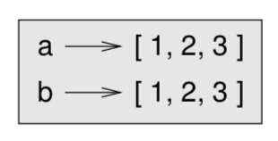

```python
a = [1, 2, 3]
b = [1, 2, 3]

a == b, a is b  # compare values, references; no aliasing
```

```
(True, False)
```

```python
a[0] = 0  # modify a

a, b  # only a has changed
```

```
([0, 2, 3], [1, 2, 3])
```

**Aliasing**: when the *same object* is know by *different names*

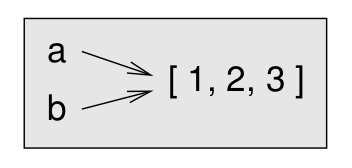

```python
a = [1, 2, 3]
b = a

a == b, a is b  # a and b are aliases
```

```
(True, True)
```

```python
a[0] = 0  # modify a

a, b  # both a and b have changed
```

```
([0, 2, 3], [0, 2, 3])
```

Since tuples and strings are immutable, aliasing never causes problems.

Aliasing (sharing) can help improve memory efficiency.

### "There are two kinds of programmers"

- Those that have been bitten by aliasing
- And those that will be

One of the quirks of imperative programming with mutable types

Adapted from: "There are two kinds of computer users"

- Those that have lost data
- And those that will

So, do make (offsite) backups!

## Strings

- A string is a *sequence* of characters
- Python has no type for single characters. Use a string of length 1.
- Strings are **immutable**. Appending to a string is expensive (involves copying).
- Strings support standard sequence operations:
  - `len`
  - indexing and slicing
  - `in`
  - `.count(target)`
- String-specific operations:
  - `.lower()`, `.upper()`, `.capitalize()`
  - `.find(target)`, `.format(...)`, `.split(delimiters)`, `.join(list)`
  - Use **TAB for code completion** and **SHIFT TAB for documentation**

```python
"abc".  # use TAB after . for code completion
```

```
  File "/var/folders/dq/bbdqxxcx30zdyfdd26t6vj4c0000gq/T/ipykernel_19616/723778573.py", line 1
    "abc".  # use TAB after . for code completion
            ^
SyntaxError: invalid syntax
```

```python
", ".join(subjects)
```

```
'mathematics, informatics, programming, modeling'
```

### Intermezzo: `join` versus `for`-loop

- `for`-loop to construct string is *inefficient*

```python
result, separator = "", ""

for subject in subjects:
    result += separator + subject  # INEFFICIENT (because of copying)!
    separator = ", "

result
```

```
'mathematics, informatics, programming, modeling'
```

```python
def capitalize_words(words: str) -> str:
    """Capitalize each word in str, and compress whitespace.
    """
    return ' '.join([word.capitalize() for word in words.split()])
```

```python
lines = ['abc def', 'hij   klm']
lines
```

```
['abc def', 'hij   klm']
```

```python
[capitalize_words(line) for line in lines]
```

```
['Abc Def', 'Hij Klm']
```

## Sequences and Iterables

- List, tuple, and string objects are *sequences*
  - They support `len`, indexing, slicing
- `map`, `filter`, and `reduce` objects are *not* sequences

### Duck typing

> "If it walks like a duck and it quacks like a duck, then it must be a duck"

*Dynamic typing*: based on supported operations, rather than birth

*Static typing*: based on declaration

```python
len(map(len, subjects))
```

```
---------------------------------------------------------------------------
TypeError                                 Traceback (most recent call last)
/var/folders/dq/bbdqxxcx30zdyfdd26t6vj4c0000gq/T/ipykernel_19616/579403691.py in <module>
----> 1 len(map(len, subjects))

TypeError: object of type 'map' has no len()
```

### Iterable

- An *iterable* is any object that can yield items one after another
  - ... is any object that can be used in a `for`-loop: `for item in iterable`
- Also see: [Python Like You Mean It: Iterables](https://www.pythonlikeyoumeanit.com/Module2_EssentialsOfPython/Iterables.html)
- Sequences are iterables
- `map` and `filter` objects are iterables

### Recap: `for` statement, a.k.a. `for`-loop

**Syntax**:

```
for item in iterable:
    statement_suite
```

**Semantics**: Successively,

- assign each value yielded by the *iterable* to *item*,
- execute the statement suite.

```python
for item in map(len, subjects):
    print(item)
```

```
11
11
11
8
```

### Notes for `for`-loops

- The iterable could be *empty*, in which case the statement suite is never executed.
- The iterable can be a string, tuple, or list.
- If the iterable is *finite*, then the `for` loop is guaranteed to *terminate*.
- **WARNING: NEVER change the iterable while iterating over it with a `for` loop!**
- You can use `break` and `continue` statements inside a `for` loop. Not recommended, however

```python
for letter in 'abstraction':
    if letter == 'i':
        break
    print(letter.upper(), end=' ')
```

```
A B S T R A C T
```

### Type hints for collections

- `List`, `Tuple`, `str`
- `Sequence`, `Iterable`

```python
from typing import List, Tuple, Sequence, Iterable, Any  # these will always be given

Tuple[float, float]  # tuple with exactly two floats
Tuple[str, ...]  # tuple with variable number of strings

List[Any]  # list with objects of any type

Sequence[int]  # sequence with integers
Iterable[str]  # iterable yielding strings
```

```
typing.Iterable[str]
```

**Advice**: In function `def`, prefer *more general* types for parameters

- Preference order: `Iterable`; `Sequence`; `List`, `Tuple`, `str`

**Advice**: In function `def`, prefer *more concrete* type for return value

### Ranges

- `range(n)` is an iterable yielding `n` integer values 0 through `n-1`. N.B. `n` is not in the range; rather, it is the length of the range.
- `range(m, n)` is iterable yielding integer values `m` through `n-1`.
- `range(m, n, s)` is an iterable with the integer values `m`, `m+s`, `m + 2*s`, ... through `n-1`. `s` is the *step size*.
- Compare to slicing: `lst[start:stop]`, `lst[start:stop:step]`

Property:

- If `a <= b <= c`, then `range(a, b)` followed by `range(b, c)` equals `range(a, c)`.

**Advice**: Use `range` in `for`-loops sparingly

- There are often better solutions
- Using `range` in a comprehension can be acceptable

```python
# print first 10 squares, starting at 0

for n in range(10):
    print(n * n)
```

```
0
1
4
9
16
25
36
49
64
81
```

```python
# print a triangle of letters "o"

for n in range(3, 0, -1):
    print(n * "o")
```

```
ooo
oo
o
```

### More built-in iterables

- `enumerate(iterable)`: yield pairs `(index, item)`
- `zip(iterable1, iterable2, ...)`: yield tuples `(item1, item2, ...)`
- `reversed(sequence)`: yield items in reversed order
- `sorted(iterable)`: yield items in sorted order

```python
word = 'Alphabet'

for index in range(len(word)):  # NOT RECOMMENDED!
    item = word[index]
    print(index, item)
```

```
0 A
1 l
2 p
3 h
4 a
5 b
6 e
7 t
```

```python
for (index, item) in enumerate('Alphabet'):
    print(index, item)
```

```
0 A
1 l
2 p
3 h
4 a
5 b
6 e
7 t
```

```python
# enumerate() yields tuples
# These tuples are "unpacked" into (index, item)
# Here, one can omit parentheses around tuple

for index, item in enumerate('Alphabet'):
    print(index, item)
```

```
0 A
1 l
2 p
3 h
4 a
5 b
6 e
7 t
```

`enumerate` also works for *iterables*, where indexing would be impossible

Note its *second* parameter, where numbering starts (default is 0):

```python
for index, item in enumerate(map(lambda s: s.capitalize(), subjects), 1):
    print(index, item)
```

```
1 Mathematics
2 Informatics
3 Programming
4 Modeling
```

### `zip` to repack multiple iterables

```python
for a, b, c in zip("ABCDE", "abcde", "12345"):
    print(a, b, c)
```

```
A a 1
B b 2
C c 3
D d 4
E e 5
```

### `zip` as matrix transpose

```python
matrix = [[1, 2, 3], [4, 5, 6]]
for row in matrix:
    print(row)
```

```
[1, 2, 3]
[4, 5, 6]
```

```python
for row in zip(*matrix):  # * will be treated later
    print(row)
```

```
(1, 4)
(2, 5)
(3, 6)
```

### Reducing iterables

- `sum(iterable)`
- `max(iterable)` `max(iterable, default)`: use `default` if `iterable` empty
- `min(iterable)` `min(iterable, default)`: use `default` if `iterable` empty
- `all(iterable)`: items interpreted as `bool` ("for all")
- `any(iterable)`: items interpreted as `bool` ("there exists")

```python
word = "Mississippi"
min(word), max(word)
```

```
('M', 's')
```

## Reading and writing text files

- `open(file_path)` and `open(file_path, 'r')` open a text file for **reading**
- `open(file_path, 'a')` opens a text file for **appending**
- `open(file_path, 'w')` opens a text file for **writing** **WARNING: Writing is destructive !!!**

Use the `with` statement to work with files.

**NOTE: The book *Think Python* doesn't do this, but it should have done so!**

- `with` is a *context manager* that will properly close the file after using it, even when errors have occurred.

```python
with open('2IS50-2223-Lecture-2-A.ipynb') as f:  # open file for reading
    lines = f.readlines()[8:20]  # extract some lines

lines
```

[output not shown]

A Jupyter notebook is basically a complex structured piece of data, encoded in a text file.

An file opened for reading is an *iterable*:

- it yields its lines as items
- N.B. these lines include the newline character `'\n'` at the end

```python
with open('2IS50-2223-Lecture-2-A.ipynb') as f:  # open file for reading
    print(sum(1 for _ in f))  # count number of lines
```

[output not shown]

**NOTE**: We used `_` (underscore) as 'anonymous' variable

Its value is used nowhere

## Turtle Graphics

See Chapter 4 of *Think Python*.

Also see: [The Beginner's Guide to Python Turtle](https://realpython.com/beginners-guide-python-turtle/) on *Real Python*

(A first encounter with recursive functions)

```python
import turtle
```

```python
t = turtle.Turtle()
t.shape("turtle")
```

A new window should have opened showing the following:

[figure not shown]

```python
def n_gon(n: int, size: int=100) -> None:
    """Draw a regular n-gon with given side lengths.
    """
    i = n

    while i > 0:
        t.forward(size)
        t.left(360 / n)
        i = i - 1
```

```python
n_gon(5)
```

Expected output in turtle window:

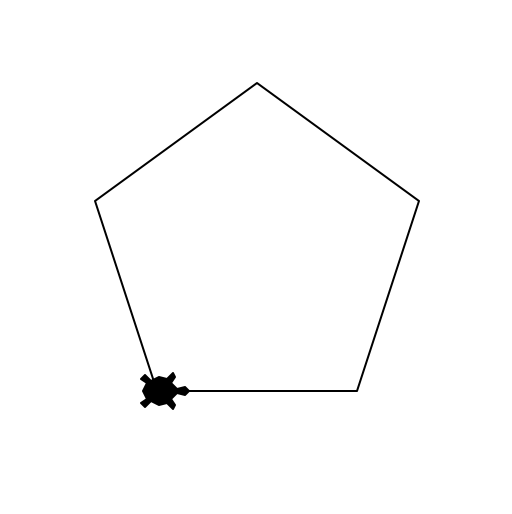

```python
t.reset()

n_gon(72, 10)
```

Expected output in turtle window (a 72-gon looks like a circle):

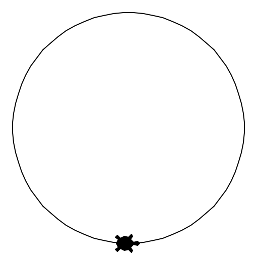

```python
def koch(t: turtle.Turtle, n: int, size: float = 100) -> None:
    """Draw a Koch fractal with n generations of given size.
    """
    t.pendown()
    if n == 0:
        t.forward(size)
    else:
        koch(t, n - 1, size / 3)
        t.left(60)
        koch(t, n - 1, size / 3)
        t.right(120)
        koch(t, n - 1, size / 3)
        t.left(60)
        koch(t, n - 1, size / 3)
```

`koch` is a recursive function: its body contains calls to itself.

```python
t.reset()
t.width(3)
t.penup()
t.goto(-turtle.screensize()[0] + 10, turtle.screensize()[1] - 10)
```

Expected output in turtle window:

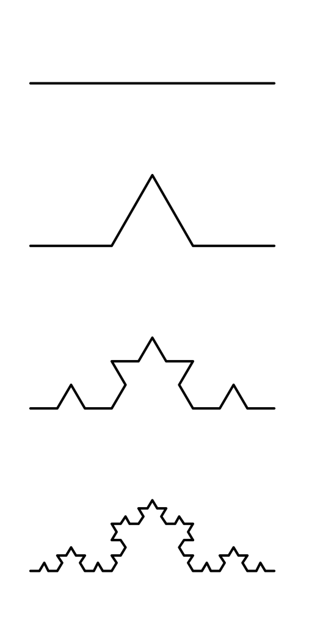

```python
for i in range(4):
    koch(t, i, 300)

    t.penup()
    t.right(90)
    t.forward(200)
    t.left(90)
    t.backward(300)
```

```python
turtle.done()
# now close window with turtle canvas
```

## (End of Notebook)

© 2019-2023 - **TU/e** - Eindhoven University of Technology - Tom Verhoeff